## Machine Learning for Stock Trading

### Part III - Rule Based Learning Strategy

**Objective:** In this notebook we will read, analyze and manipulate historical financial data.  
In next part we will use this data to predict stock price using machine learning algorithms.

```python
import pandas as pd
import datetime as dt
import matplotlib.pyplot as plt
import numpy as np
from util import get_data
from marketsim import compute_portvals
from indicators import getSMA, getBB, getmomentum
import warnings
warnings.filterwarnings('ignore')
```

**Data Format:**  
Stock symbol: JPM  
In-Sampleperiod: January 1, 2008 to December 31 2009.  
Out-Sample: January 1, 2010 to December 31 2011.  
Starting Value: 100,000.  
Allowable positions: 1000 shares long, 1000 shares short, 0 shares.  
There is no limit on leverage.  
Transaction costs: Commission: $9.95, Impact: 0.005.

```python
startdt = dt.datetime(2008,1,1)
enddt = dt.datetime(2009,12,31)
symbols = ['JPM']
startval = 100000
commission = 0
impact = 0

# Get Portfolio Benchmark
dates = pd.date_range(startdt, enddt)
prices = get_data(symbols, dates)
prices = prices.fillna(method="ffill")
prices = prices.fillna(method="bfill")
prices = prices.drop(['SPY'], axis=1)
pricesnormed = prices/prices.ix[0,]
```

**Technical Indicators:** Technical indicators are a fundamental part of technical analysis and are typically plotted as a chart pattern to try to predict the market trend. Indicators generally overlay on price chart data to indicate where the price is going, or whether the price is in an "overbought" condition or an "oversold" condition.

Trading strategy is built upon following three technical indicators which helps in making buy, sell or do-nothing decisions.

1. **Simple Moving Average:** Simple moving average (SMA) smooths out past price data. It calculates the rolling mean price of a stock for specified lookback periods. It is used in many different technical indicators and it can also serve as a stand-alone indicator for analyzing price movement.  
   As SMA smooths out the noise in the stock prices and generate buy or sell signals by identifying trend direction. SMA serves as the support line for stock price. If stock prices move significantly from SMA, price tends to come back to SMA. Strategy is to buy stock when stock price falls significantly below the SMA and to short the stock when stock price rise significantly above SMA.  
   In order to capture this indicator, we calculate the ration of price to SMA and buy stock when price to SMA ratio is below threshold and buy stock when price to SMA ratio is above threshold. Below graph was plotted for JPM stock for look back window of 20 days.

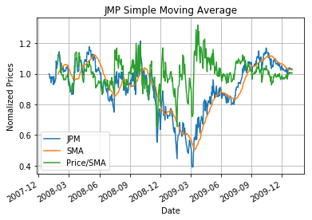

```python
def getSMA(prices, lookback=20):
    sma = prices.rolling(window=lookback, min_periods=lookback).mean()
    smapricesratio = prices/sma
    smadf = pd.concat([prices, sma, smapricesratio], axis=1)
    smadf.columns = ['JPM', 'SMA', 'Price/SMA']
    return smadf

getSMA(pricesnormed).plot(grid=True, title='JMP Simple Moving Average', use_index=True)
plt.ylabel('Nomalized Prices')
plt.xlabel('Date')
plt.show()
```

1. **Bollinger Bands:** This indicator expands on the Simple Moving Average (SMA) by including standard deviation of prices from the SMA. Bollinger Bands detects the volatility and dynamics of the price movement in the stock price. Using Bollinger Bands, we can predict whether current trend in the stock price will continue or turn around.  
   Central line in the Bollinger bands represents the Simple Moving Average (SMA). Upper and lower lines of band represent the + and - 2 standard deviations of stock price from the SMA respectively.  
   When stock price fluctuates highly, gap between upper and lower bands is largest. Gap is lowest when prices fluctuation is less. If the price is close to or outside of the upper band, the stock price would be considered high and investor should sell the stock. On the other hand, if the price is near the lower band, stock price would be considered low and investor should buy the stock.  
   Bollinger Band Percentage (%B) is calculated by subtracting the lower band from the price and then dividing it by the difference between upper and lower bands. This BBP is thus less than zero when the price falls below the lower band and is greater than 1 when the price rises above the upper band. The Bollinger Band family is plotted on the same stock data.
- *Middle Band = SMA with look back window of 20 days*
- *Upper Band = SMA + (2 x standard deviation of price)*
- *Lower Band = SMA - (2 x standard deviation of price)*
- *%B = (Current Price - Lower Band) / (Upper Band - Lower Band)*

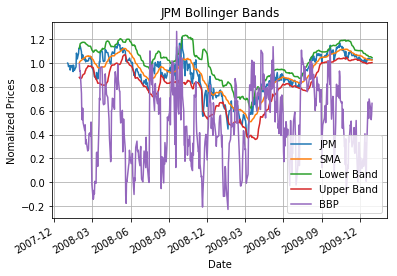

```python
def getBB(prices, lookback=20):
    sma = prices.rolling(window=lookback, min_periods=lookback).mean()
    rollingstd=prices.rolling(window=lookback,min_periods=lookback).std()
    top = sma+(2*rollingstd)
    bottom = sma-(2*rollingstd)
    bbpct = (prices-bottom)/(top-bottom)
    bbandsdf = pd.concat([prices, sma, top, bottom, bbpct], axis=1)
    bbandsdf.columns = ['JPM', 'SMA', 'Lower Band', 'Upper Band', "BBP"]
    return bbandsdf

getBB(pricesnormed).plot(grid=True, title='JPM Bollinger Bands', use_index=True)
plt.ylabel('Nomalized Prices')
plt.xlabel('Date')
plt.show()
```

1. **Momentum:** This technical indicator help investor to predict strength of a price movement. Momentum is calculated by comparing the most recent closing price to a previous closing price over the lookback window. Below chart displays the momentum indicator as a single line and a separate stock price line for JPM is also shown in the chart.  
   *M = CP – CPn*  
   Where M is momentum, CP is closing price and n is lookback window. If the current price is higher than the price in the past, then the Momentum is positive. On the other hand, if the current price is lower than the price in the past, then the Momentum is negative. When the Momentum crosses above the zero-line stock price is reversing and price is bottomed out hence it is a buy signal. When the Momentum crosses below the zero-line stock price is reversing and price is topped out hence it is a sell signal.

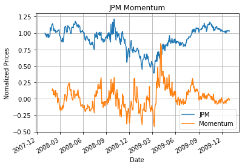

```python
def getmomentum(prices, lookback=20):
    momentum = (prices/prices.shift(lookback))-1
    momentumdf = pd.concat([prices, momentum], axis=1)
    momentumdf.columns = ['JPM', 'Momentum']
    return momentumdf

getmomentum(pricesnormed).plot(grid=True, title='JPM Momentum', use_index=True)
plt.ylabel('Nomalized Prices')
plt.xlabel('Date')
plt.savefig('JPM_Momentum.png')
```

**Theoretically Optimal Strategy:** Assuming we can peek into future but constrained by the portfolio size and order limits we create a set of trades that represents the best a strategy could possibly do during the in sample period.

Objective is to identify the upper bound on performance.

The intent is for you to use adjusted close prices with the market simulator. For this activity, we assume commissions and impact $0.00, and 0.0 respectively.

```python
# Calculate benckmark performance
benchmarkprices = pd.DataFrame(0, index = prices.index, columns = ["Symbol", "Order", "SharesCnt"])
benchmarkprices['SharesCnt'][0] = 1000
benchmarkprices['Date'] = prices.index
benchmarkprices['Symbol'] = 'JPM'
benchmarkprices['Order'] = "BUY"
benchmarkportval = compute_portvals(benchmarkprices,start_val=startval,commission=commission,impact=impact)

normedbenchmarkportval = benchmarkportval/benchmarkportval.ix[0]

daily_ret = (normedbenchmarkportval / normedbenchmarkportval.shift(1)) - 1
cr = (normedbenchmarkportval[-1] / normedbenchmarkportval[0]) - 1
adr = daily_ret.mean()
sddr = daily_ret.std()

print "Cumulative Return of Benchmark: {}".format(cr)
print
print "Standard Deviation of Benchmark: {}".format(sddr)
print
print "Average Daily Return of Benchmark: {}".format(adr)
print
```

```
Cumulative Return of Benchmark: 0.0123

Standard Deviation of Benchmark: 0.0170043662712

Average Daily Return of Benchmark: 0.000168086978191
```

```python
#Calulate Theoratically Optimal Portfolio
trades = []
holdlimit = 0
for i in range(len(prices)-1):
    # print(holdlimit)
    if prices.ix[i,'JPM'] < prices.ix[i + 1,'JPM']:
        if holdlimit == 0:
            holdlimit += 1000
            trades.append([prices.index[i], 'JPM', 'BUY', 1000])
        elif holdlimit == 1000:
            trades.append([prices.index[i], 'JPM', 'NOTHING',  0])
        else:
            holdlimit += 2000
            trades.append([prices.index[i], 'JPM', 'BUY',  2000])
    elif prices.ix[i,'JPM'] > prices.ix[i + 1,'JPM']:
        if holdlimit == 0:
            holdlimit -= 1000
            trades.append([prices.index[i], 'JPM', 'SELL',  1000])
        elif holdlimit == -1000:
            trades.append([prices.index[i], 'JPM', 'NOTHING', 0])
        else:
            holdlimit -= 2000
            trades.append([prices.index[i], 'JPM', 'SELL', 2000])
    else:
        trades.append([prices.index[i], 'JPM', 'NOTHING', 0])

df_trades = pd.DataFrame(trades, columns=["Date", "Symbol", "Order", "SharesCnt"])
df_trades.set_index('Date',inplace=True)


# Get Optimal Portfolio
df_trades['Symbol'] = 'JPM'
optimalportval = compute_portvals(df_trades,start_val=startval,commission=commission,impact=impact)
normedoptimalportval = optimalportval/optimalportval.ix[0]

daily_ret = (normedoptimalportval/normedoptimalportval.shift(1)) - 1
cr = (normedoptimalportval[-1]/normedoptimalportval[0]) - 1
adr = daily_ret.mean()
sddr = daily_ret.std()

print "Cumulative Return of Optimal Portfolio: {}".format(cr)
print
print "Standard Deviation of Optimal Portfolio: {}".format(sddr)
print
print "Average Daily Return of Optimal Portfolio: {}".format(adr)
print
```

```
Cumulative Return of Optimal Portfolio: 5.7848

Standard Deviation of Optimal Portfolio: 0.00454946867438

Average Daily Return of Optimal Portfolio: 0.00382399327091
```

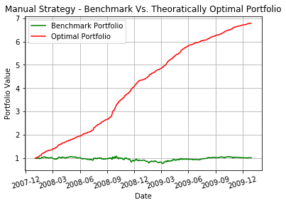

```python
# Plot Benchmark Vs. Theoratically Optimal Portfolio

plt.plot(normedbenchmarkportval, color='green', label='Benchmark Portfolio')
plt.plot(normedoptimalportval, color='red', label='Optimal Portfolio')

plt.title('Manual Strategy - Benchmark Vs. Theoratically Optimal Portfolio')
plt.ylabel('Portfolio Value')
plt.xlabel('Date')
plt.xticks(rotation=15)
plt.grid(True)
plt.legend()
plt.show()
```

**Analysis:** In order to understand upper bounds of performance a theoretically optimal strategy is developed by peaking into future on the in-sample data. To generate optimal trades market simulator code built in previous project was used along with adjusted close price of JPM stock. For this task commission and impact was assumed to be $0.00 and 0.0 respectively. In sample period is from January 1, 2008 to December 31, 2009.  
To generate optimal trades, a logic was developed looking at next day’s stock price. If the difference between today’s price and tomorrow’s price is positive i.e. today’s price is greater than tomorrow’s price, then stock is sold. On the other hand, if the difference between today’s price and tomorrow’s price is negative i.e. today’s price is less than tomorrow’s price then stock is bought. Strategy was constrained by allowable positions of 1000 shares long, 1000 shares short and 0 shares, hence trading quantity was limited to 2000 shares. A logic was expanded to calculate quantity of shares to be traded based up the current holding quantity of the stock.  
Below chart represents the implementation of theoretically optimal strategy for JPM for in sample dataset. As it can be observed from the chart and statistics below, theoretically optimal strategy performs very well as compared to benchmark.

**Manual Rule-Based Trader:** In this section we implement a set of rules using the indicators discussed above and devise some simple logic using indicators to enter and exit positions in the stock.

A rule based manual strategy was implemented in this section. This strategy leverages the technical indicators implemented in part 1 of this project to generate trades using market simulator code developed in previous project.  
Following logic was developed to generate buy, sell or do nothing signals. Buy or sell is triggered when all three indicators meets the thresholds.

- Buy stock if momentum is less than 0.05 and Bollinger’s Band percentage is less than 0.15 and price to SMA ratio is less than 0.85.
- Sell the stock if momentum is greater than 0.05 and Bollinger’s Band percentage is greater than 0.15 and price to SMA ratio is greater than 1.02.  
  Note that Buy, Sell or Do Nothing decision was also constrained by allowable positions of 1000 shares long, 1000 shares short and 0 shares, hence trading quantity was limited to 2000 shares. A logic was expanded to calculate quantity of shares to be traded based up the current holding quantity of the stock.

```python
# Get indicators and implement rule to enter and exit stock positions.

smadf = getSMA(pricesnormed, 20)
bbandsdf = getBB(pricesnormed, 20)
momentumdf = getmomentum(pricesnormed, 20)

manstratport = pd.DataFrame(0, index = pricesnormed.index, columns = ["Symbol", "Order", "SharesCnt"])
manstratport['Date'] = prices.index
manstratport['Symbol'] = 'JPM'
manstratport['Order'] = "BUY"

holdlimit = 0
for i in range(len(pricesnormed)-1):
    sma = smadf.ix[i, 'SMA']
    pr2sma = smadf.ix[i, 'Price/SMA']
    bbp = bbandsdf.ix[i, 'BBP']
    momentum = momentumdf.ix[i, 'Momentum']

    if (momentum < 0.05) and (bbp < 0.15) and (pr2sma < 0.85):
        if holdlimit == 0:
            holdlimit += 1000
            manstratport.ix[i,'Order'] = 'BUY'
            manstratport.ix[i,'SharesCnt'] = 1000
        elif holdlimit == 1000:
            manstratport.ix[i,'Order'] = 'NOTHING'
            manstratport.ix[i,'SharesCnt'] = 0
        else:
            holdlimit += 2000
            manstratport.ix[i,'Order'] = 'BUY'
            manstratport.ix[i,'SharesCnt'] = 2000
    elif (momentum > 0.05) and (bbp > 0.15) and (pr2sma > 1.02):
        if holdlimit == 0:
            holdlimit -= 1000
            manstratport.ix[i,'Order'] = 'SELL'
            manstratport.ix[i,'SharesCnt'] = 1000
        elif holdlimit == -1000:
            manstratport.ix[i,'Order'] = 'NOTHING'
            manstratport.ix[i,'SharesCnt'] = 0
        else:
            holdlimit -= 2000
            manstratport.ix[i,'Order'] = 'SELL'
            manstratport.ix[i,'SharesCnt'] = 1000
    else:
        manstratport.ix[i,'Order'] = 'NOTHING'
        manstratport.ix[i,'SharesCnt'] = 0

manstratportval = compute_portvals(manstratport,start_val=startval,commission=commission,impact=impact)
# print(benchmarkportval)
normedmanstratportval = manstratportval/manstratportval.ix[0]

daily_ret = (normedmanstratportval/normedmanstratportval.shift(1)) - 1
cr = (normedmanstratportval[-1]/normedmanstratportval[0]) - 1
adr = daily_ret.mean()
sddr = daily_ret.std()

print "Cumulative Return of Manual Strategy Portfolio: {}".format(cr)
print
print "Standard Deviation of Manual Strategy Portfolio: {}".format(sddr)
print
print "Average Daily Return of Manual Strategy Portfolio: {}".format(adr)
print
```

```
Cumulative Return of Manual Strategy Portfolio: 0.5573

Standard Deviation of Manual Strategy Portfolio: 0.0207614156378

Average Daily Return of Manual Strategy Portfolio: 0.00109325593932
```

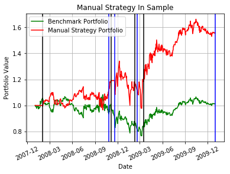

```python
# In Sample
plt.figure(0)
plt.plot(normedbenchmarkportval, color='green', label='Benchmark Portfolio')
plt.plot(normedmanstratportval, color='red', label='Manual Strategy Portfolio')
for i, row in manstratport.iterrows():
    if manstratport.ix[i,"Order"] == "SELL":
        plt.axvline(x=i, color='black')
    elif manstratport.ix[i,"Order"] == "BUY":
        plt.axvline(x=i, color='blue')

plt.title('Manual Strategy In Sample')
plt.ylabel('Portfolio Value')
plt.xlabel('Date')
plt.xticks(rotation=25)
plt.grid(True)
plt.legend()
plt.show()
```

```
Cumulative Return of Manual Strategy Portfolio: 0.492768530469

Standard Deviation of Manual Strategy Portfolio: 0.0213929991452

Average Daily Return of Manual Strategy Portfolio: 0.00102235803628
```

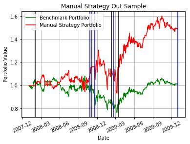

```python
# Out Sample Charts
startdt = dt.datetime(2010,1,1)
enddt = dt.datetime(2011,12,31)
symbols = ['JPM']
startval = 100000
commission = 9.95
impact = 0.005

manstratport = pd.DataFrame(0, index = pricesnormed.index, columns = ["Symbol", "Order", "SharesCnt"])
manstratport['Date'] = prices.index
manstratport['Symbol'] = 'JPM'
manstratport['Order'] = "BUY"

holdlimit = 0
for i in range(len(pricesnormed)-1):
    sma = smadf.ix[i, 'SMA']
    pr2sma = smadf.ix[i, 'Price/SMA']
    bbp = bbandsdf.ix[i, 'BBP']
    momentum = momentumdf.ix[i, 'Momentum']

    if (momentum < 0.05) and (bbp < 0.15) and (pr2sma < 0.85):
        if holdlimit == 0:
            holdlimit += 1000
            manstratport.ix[i,'Order'] = 'BUY'
            manstratport.ix[i,'SharesCnt'] = 1000
        elif holdlimit == 1000:
            manstratport.ix[i,'Order'] = 'NOTHING'
            manstratport.ix[i,'SharesCnt'] = 0
        else:
            holdlimit += 2000
            manstratport.ix[i,'Order'] = 'BUY'
            manstratport.ix[i,'SharesCnt'] = 2000
    elif (momentum > 0.05) and (bbp > 0.15) and (pr2sma > 1.02):
        if holdlimit == 0:
            holdlimit -= 1000
            manstratport.ix[i,'Order'] = 'SELL'
            manstratport.ix[i,'SharesCnt'] = 1000
        elif holdlimit == -1000:
            manstratport.ix[i,'Order'] = 'NOTHING'
            manstratport.ix[i,'SharesCnt'] = 0
        else:
            holdlimit -= 2000
            manstratport.ix[i,'Order'] = 'SELL'
            manstratport.ix[i,'SharesCnt'] = 1000
    else:
        manstratport.ix[i,'Order'] = 'NOTHING'
        manstratport.ix[i,'SharesCnt'] = 0

manstratportval = compute_portvals(manstratport,start_val=startval,commission=commission,impact=impact)
# print(benchmarkportval)
normedmanstratportval = manstratportval/manstratportval.ix[0]

daily_ret = (normedmanstratportval/normedmanstratportval.shift(1)) - 1
cr = (normedmanstratportval[-1]/normedmanstratportval[0]) - 1
adr = daily_ret.mean()
sddr = daily_ret.std()

print "Cumulative Return of Manual Strategy Portfolio: {}".format(cr)
print
print "Standard Deviation of Manual Strategy Portfolio: {}".format(sddr)
print
print "Average Daily Return of Manual Strategy Portfolio: {}".format(adr)
print



plt.figure(1)
plt.plot(normedbenchmarkportval, color='green', label='Benchmark Portfolio')
plt.plot(normedmanstratportval, color='red', label='Manual Strategy Portfolio')
for i, row in manstratport.iterrows():
    if manstratport.ix[i,"Order"] == "SELL":
        plt.axvline(x=i, color='black')
    elif manstratport.ix[i,"Order"] == "BUY":
        plt.axvline(x=i, color='blue')

plt.title('Manual Strategy Out Sample')
plt.ylabel('Portfolio Value')
plt.xlabel('Date')
plt.xticks(rotation=25)
plt.grid(True)
plt.legend()
plt.show()
```